# Simulation exercise in **Genomik und Bioinformatik**

# Screening Noise

In any sample of a single specific tissue, at most half of the genes are actually expressed. Hence, a microarray as discussed in Chapter 13 measures only noise in half of the genes. In this assignment, we simulate the strongest expression levels caused by noise and illustrate the corresponding distribution.

**Question (a):** Simulate a matrix of random expression values using `R`’s random number generator to draw from a normal distribution with a mean of 6 and a standard deviation of 1. The matrix is to contain values for 500 samples and 10000 genes.

```r
> genes <- 10000 #rows
> samples <- 500 #columns
>
> myDistr <- rnorm(genes*samples, 6, 1)
> dim(myDistr) <- c(genes, samples)
```

**Question (b):** For each sample in your matrix, find the maximum simulated expression level and plot a histogram of these maxima. To the histogram, add the mean value of your distribution using the functions `abline` and `mtext`. Does the histogram resemble a normal distribution? Explain.

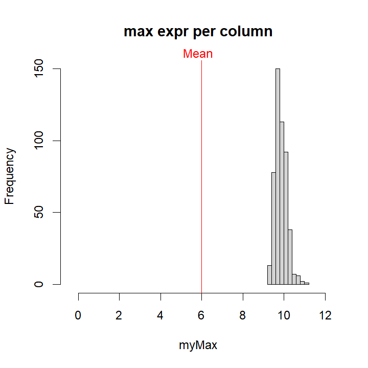

```r
> myMax <- apply(myDistr, 2, max)
> hist(myMax, main = "max expr per column", xlim = c(min(myDistr)-1, max(myDistr)+1))
> myMean <- mean(myDistr)
> abline(v = myMean, col = "red")
> mtext("Mean", side = 3, col = "red", line = 0, outer=FALSE)
```

**Question (c):** Why is the histogram somewhat bumpy? Help to fix this issue by plotting a smoothed density instead of the histogram by using the function `density`.

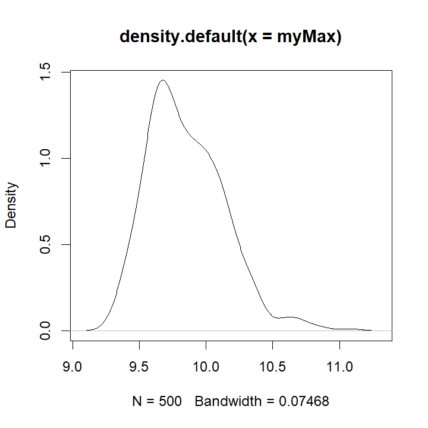

```r
> dens <- density(myMax)
> plot(dens)
```

**Question (d):** Use the function `qqnorm` to make a Q-Q plot of the maxima against a normal distribution. Describe the interpretation of the form of a normal Q-Q plot in your own words. As a help for interpretation, add a line to the normal Q-Q-plot using the `qqline` function. Describe how this line is generated and how it helps to interpret a Q-Q-plot. Mimic the `qqnorm` function only using the functions `plot` and `rnorm` in order to understand the mechanism. Do the simulated maxima resemble a normal distribution according to your own Q-Q-plot?

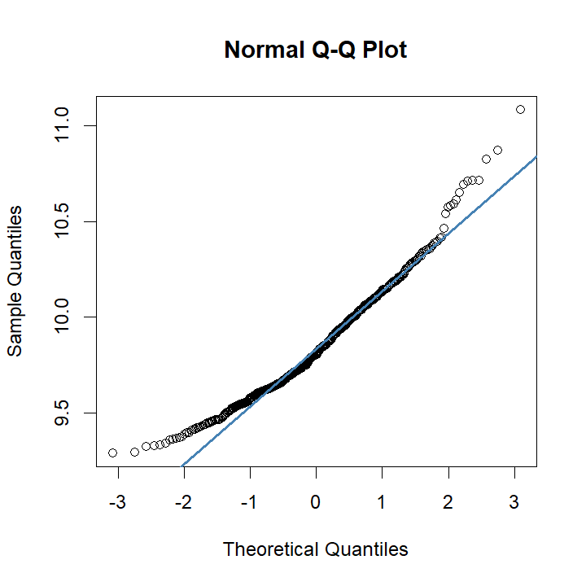

```r
> qqnorm(myMax)
> qqline(myMax, col="steelblue", lw=2)
```

**Answer:** A `qqplot` is generated by comparing a normal distribution with another arbitrary distribution. First both distributions are sorted and then plotted against each other, i.e. the x-value of first quantile of distribution 1 against x-value of first quantile of distribution 2 and so on. `qqline` plots a normal distribution against a normal distribution and is therefore always straight. In our example the `qqplot` is not following the straight blue `qqline`, indicating that our random maxima values do not follow a normal distribution.

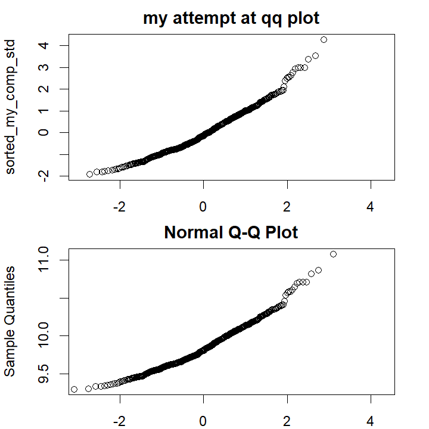

```r
> std_comp <- sd(myMax)
> mean_comp <- mean(myMax)
>
> sorted_my_comp <- sort(myMax, decreasing=FALSE)
> sorted_my_comp_std <- (sorted_my_comp-mean_comp)/std_comp
>
> my_std2 <- quantile(rnorm(10000), prob=seq(0,1,1/(length(myMax))))
>
> par(mar=c(2, 4, 2, 2))
> par(mfrow=c(2,1))
> plot(x=my_std2[1:(length(my_std2))-1], y=sorted_my_comp_std, main="my attempt at qq plot", xlim=c(min(sorted_my_comp_std)-1, max(sorted_my_comp_std)), xlab="")
>
> qqnorm(myMax, xlim=c(min(sorted_my_comp_std)-1, max(sorted_my_comp_std)))
```

**Answer:** The graphs do not exactly look the same because `qqnorm` apparently takes a smooth normal distribution $f(x)=\frac{1}{\sqrt{2\pi\sigma^2}} e^{-\frac{(x-\mu)^2}{2\sigma^2}}\quad$. But I took random discrete values created by `rnorm` and hoping that the first element of my distribution lines approximately up with the first quantile calculated by `quantile()`.

Ideally one would solve the antiderivative $F(x)$ for 100 quantiles. But solving $F(x)=1/100$ for $x$ with $F(x) = \frac{1}{\sigma\sqrt{2\pi}} \int_{-\infty}^x e^{-\frac{1}{2} \left(\frac{t-\mu}{\sigma}\right)^2} \mathrm dt$ seems complicated.